# CFB Elo Ratings

Phil Henrickson

2022-06-22

# What is this?

This notebook explores creating Elo ratings for college football teams using data from the late 1800s to present.

# 1 The Data

The data we’re using is at the game level, in which we have features indicating the season, the week, the location, the teams, and the score.

| GAME_ID | SEASON | WEEK | VENUE | HOME_TEAM | AWAY_TEAM | HOME_POINTS | AWAY_POINTS | HOME_WIN |
| --- | --- | --- | --- | --- | --- | --- | --- | --- |
| 252880062 | 2005 | 7 | Aloha Stadium | Hawai'i | New Mexico State | 49 | 28 | yes |
| 400547651 | 2014 | 2 | John O'Quinn Field at TDECU Stadium | Houston | Grambling | 47 | 0 | yes |
| 272792638 | 2007 | 6 | Sun Bowl Stadium | UTEP | Tulsa | 48 | 47 | yes |
| 243110052 | 2004 | 11 | Bobby Bowden Field at Doak Campbell Stadium | Florida State | Duke | 29 | 7 | yes |
| 400869312 | 2016 | 8 | Brigham Field at Huskie Stadium | Northern Illinois | Buffalo | 44 | 7 | yes |

We also have additional features on team conferences, attendance, start time, betting line, as well as information from an existing Elo Model. We’ll set that aside for now, as our goal here is to go through the process of developing our own Elo model.

We lose some information the further we go back, but we have outcomes of games back to the very first game between Rutgers and Princeton in 1869.

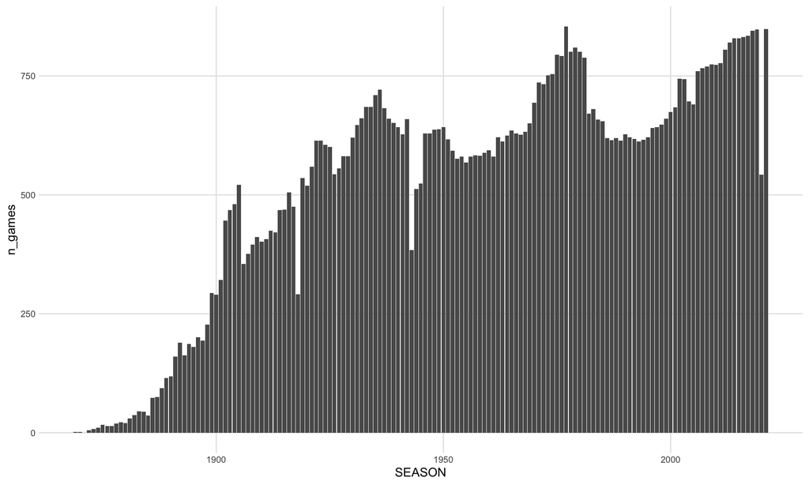

# 2 Elo Ratings

What exactly is an Elo rating? It takes its name from the guy who first came up with the idea, Arpad Elo, who developed it for the purpose of ranking chess players: https://en.wikipedia.org/wiki/Elo_rating_system. I note this because people commonly refer to these as ELO scores - no, it’s Elo, it’s from his name.

The basic idea is to, for any given matchup between opponents, assign a rating to each opponent that can be used to predict the outcome of the match. The result of the match will then influence their ensuing ratings, with the winner gaining points from the loser. An opponent’s rating is always a function of prior results, taking into account their performance in previous matches as well as the ratings of their opponents.

## 2.1 The Expected Score

For the full description of how this works, check out the Wikipedia page, but I’ll paraphrase it here to the best of my ability. Say we’ve got an upcoming match between two opponents, $A$ and $B$. In an Elo rating system, the expected result, or score, for Opponent $A$ in a match against Opponent $B$ is:
$$E_A = \frac{1}{1+10^{(R_B-R_A)/V}}$$

What does this equation mean?

- $E_A$ is Opponent’s A expected score from the match - in the case of matchup between two opponents, this basically just reduces to win probability.
- $R_A$ is Opponent A’s pre match rating
- $R_B$ is Opponent B’s pre match rating
- 10 is the base value used in the rating system; typically 10 is used in these types of ratings
- V is a scaling factor that sets how much a difference in rating between the two opponents will affect the probability of either side winning. More on this in a second.

How did we get this equation? It’s just a logistic curve of the form $f(x) = \frac{1}{1+e^{-x}}$, which is the standard logistic function with a growth rate and curve maximum of 1. Don’t worry about this too much, it basically just constrains any input of x to return a number between 0 and 1.

Similarly, the expected score for Opponent B is:
$$E_B = \frac{1}{1+10^{(R_A-R_B)/V}}$$

What’s the point of this equation? We can input ratings for $A$ and $B$ and get back an expected score for an opponent based on the difference between the two opponent’s rating.

```r
get_expected_score <- function(R_A, R_B, V=400) {

        return(1 / (1 + 10^((R_B - R_A) / V)))

        }
```

If the two opponents have equal ratings, the difference between their rating is zero, and the the expected score reduces to 0.5. Why? When the difference is zero, anything raised to the 0 is 1, and the scaling factor no longer matters:
$$E_A = \frac{1}{1+10^{0/V}} = \frac{1}{1+1} = \frac{1}{2}$$

So, anytime we have two perfectly equal opponents, the expected score reduces to a coin flip.

Okay, but now suppose that $R_A$ is 100 and $R_B$ is 50 and $V$ is 200. Plugging these numbers into the equation above, we get an expected score for A of 0.6401. In this case, $A$ is more likely to win, as they have a higher rating. In this case, the scaling factor $V$ determines how much the difference in rating matters for the expected score:

$$E_A = \frac{1}{1+10^{(50-100)/200}} = \frac{1}{1+10^{-50/200}} = \frac{1}{1+10^{-1/4}} \approx \frac{1}{1+.5623} \approx 0.64$$
If the scaling factor $V$ was set to 50, the difference in rating between these two teams would be considered much bigger.

$$E_A = \frac{1}{1+10^{(50-100)/50}} = \frac{1}{1+10^{-50/50}} = \frac{1}{1+10^{-1}} \approx \frac{1}{1+.0.1} \approx 0.909$$
Tangibly, this means the scaling factor indicates the difference at which one opponent’s expected score would be ten times greater than their opponent’s expected score. I’ll plot the expected score for $A$ as a function of the difference between $R_B$ and $R_A$ using different values of $V$ for the scaling factor.

[figure not shown]

All this is to say that the selection of the scaling factor and the initial Elo values determine the scaling of the ratings, and we can make decisions about these.

## 2.2 Updating Elo Ratings

But none of this so far gets to the real heart of why Elo ratings prove to be useful, which is that they are always updating based on new results. After a match between opponents, the outcome of the match determines each opponent’s updated rating.

As we said earlier, before the match, $R_A$ is 100 and $R_B$ is 50 and $V$ is 200. After the match, we recalculate each opponent’s score taking into account what happened in the match. How do we do this? The equation looks like this:

$$R'_A = R_A + K*(S_A - E_A)$$
We update $R'_A$ based on the previous rating plus the difference between what they actually scored $S_A$ minus what they were expected to score $E_A$, multiplied by the $K$-factor, which determines the maximum possible adjustment between games.

```r
 update_team_rating <- function(team_rating,
                           observed_score,
                           expected_score,
                           k_factor = 10) {

         return(team_rating + k_factor * (observed_score - expected_score))

 }
```

Let’s say that that $A$ lost the match to $B$. Their initial score was 100. If the k-factor is set to 10, the most their score could drop is 10 points. They will drop by slightly less than that, based on their expected score:

$$R'_A = 100 + 10*(0 - 0.64) \approx 93.6$$
$B$, on the other hand, would get a boost to their rating.

$$R'_B = 50 + 10*(1 - 0.36) \approx 56.4$$

In this way, the winner picks up points from the loser, and the scaling factor K determines how many points can be transferred in one match.

# 3 Elo Ratings and CFB Games

Okay, so at this point we have what we need in order to build out Elo Ratings for college football games. We could start this analysis going back all the way to 1869 as the starting point, but I’ll start at 1980 for now since I’m at least somewhat familiar with teams in this era and will be able to eyeball the results.

I’ll set every team’s initial rating to 1500 and the scaling factor to 400. The appropriate value for K is something that I’ll want to explore empirically, but I’ll start it at 25 and go from there.

[output not shown]

[output not shown]

[output not shown]

[output not shown]

[output not shown]

[output not shown]